# Ford GoBike System Exploratory Data Analysis

## by Wahab Hamed Ayomide

## Investigation Overview

> In this investigation, we will analyze the time of the day and day of the week that most trips are taken, the type of users taking the rides and the duration of the rides.

## Dataset Overview

> This data set includes information about individual rides made in a bike-sharing system covering the greater San Francisco Bay area.
- There are 183,412 rides made in the dataset with 16 details ('duration_sec', 'start_time', 'end_time', 'start_station_id', 'start_station_name', 'start_station_latitude','start_station_longitude', 'end_station_id', 'end_station_name', 'end_station_latitude', 'end_station_longitude', 'bike_id', 'user_type','member_birth_year', 'member_gender', 'bike_share_for_all_trip') about the rides.

## Rides during time of day (Morning/Afternoon/Evening/Night)

The below visualization shows that number of rides taken on different time of the day (Morning/Afternoon/Evening/Night).

- It could be seen from the plot that the time of the day with the most rides is Morning (00:00 - 11:59 hours of the day) followed by Afternoon and Evening, then Night. Understandably, the least number of rides are taken in the night.

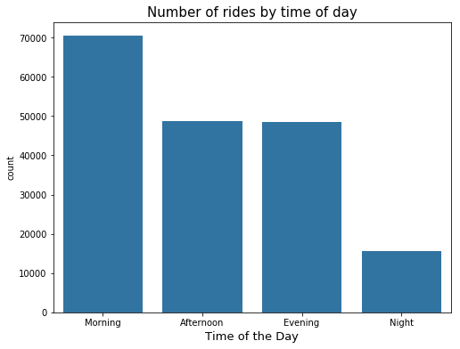

## Rides by User types

As evidently seen from the plot, most trips (about 89%) are taken by the subscribers with the remaining (about 11%) being just casual riders.

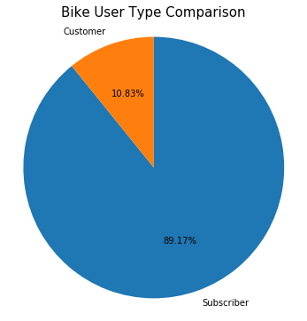

## Service Usage by Day of the Week and User type

From the plot, the day of the week that most rides are taken (Thursday) is not dependent on if the user is a subscriber or a customer. Although, we can see the reduced number of rides from subscribers on weekends. This could mean that subscribers might be regularly using the bikes for work and home commute purposes and customers use it for recreational or exercise activities during weekends.

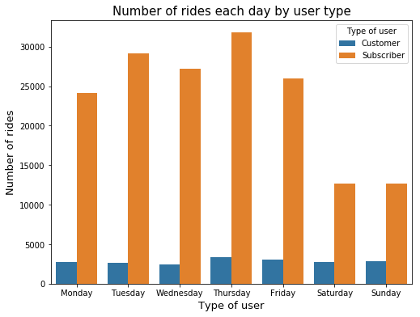

## Hourly Usage per Day

Most Subscribers use the service at peak hour (8am and 5pm). In contrast, Customers have more flexible time mostly in early hours of the evening (5pm)

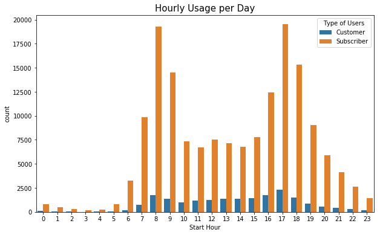

## Ride Duration by Day of the Week and User type

On each day of the week, customer rides lasted longer than the subscriber users and even more significantly on weekends.

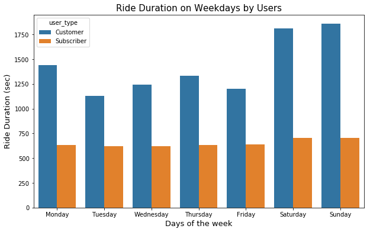